# A Case Study on Retail Giant Sales/Demand Time Series Forecasting :

**Objective:**  
Identify top 2 consistently profitable market segments of Global Mart and forecast Sales & Demand for next 6 months in those Market Segments using Time Series Analysis

## Business understanding

Global Mart is an online store super giant having worldwide operations. The store caters to 7 different geographies(Markets) and in 3 major segments. The goal is to identify top 2 consistently profitable market segments of Global Mart and forecast Sales & Demand for next 6 months in those Market Segments using Time Series Analysis

*Installing & Loading required packages* Check and Import required libraries

```r
options(warn = -1)
libs = c("tidyverse", "lubridate", "graphics", "forecast", "tseries")
install.lib <- libs[!libs %in% installed.packages()]
for (pkg in install.lib)
  install.packages(pkg, dependencies = T)
loadlib     <- lapply(libs, library, character.only = T) # load them
remove(list = ls())
options(warn = 0)
```

*Import Dataset*

```r
superstore <-  read.csv("Global Superstore.csv", stringsAsFactors = F)
```

## Data Understanding

```r
dim(superstore)
```

```
## [1] 51290    24
```

```r
glimpse(superstore)
```

```
## Observations: 51,290
## Variables: 24
## $ Row.ID         <int> 32298, 26341, 25330, 13524, 47221, 22732, 30570...
## $ Order.ID       <chr> "CA-2012-124891", "IN-2013-77878", "IN-2013-712...
## $ Order.Date     <chr> "31-07-2012", "05-02-2013", "17-10-2013", "28-0...
## $ Ship.Date      <chr> "31-07-2012", "07-02-2013", "18-10-2013", "30-0...
## $ Ship.Mode      <chr> "Same Day", "Second Class", "First Class", "Fir...
## $ Customer.ID    <chr> "RH-19495", "JR-16210", "CR-12730", "KM-16375",...
## $ Customer.Name  <chr> "Rick Hansen", "Justin Ritter", "Craig Reiter",...
## $ Segment        <chr> "Consumer", "Corporate", "Consumer", "Home Offi...
## $ City           <chr> "New York City", "Wollongong", "Brisbane", "Ber...
## $ State          <chr> "New York", "New South Wales", "Queensland", "B...
## $ Country        <chr> "United States", "Australia", "Australia", "Ger...
## $ Postal.Code    <int> 10024, NA, NA, NA, NA, NA, NA, NA, 95823, 28027...
## $ Market         <chr> "US", "APAC", "APAC", "EU", "Africa", "APAC", "...
## $ Region         <chr> "East", "Oceania", "Oceania", "Central", "Afric...
## $ Product.ID     <chr> "TEC-AC-10003033", "FUR-CH-10003950", "TEC-PH-1...
## $ Category       <chr> "Technology", "Furniture", "Technology", "Techn...
## $ Sub.Category   <chr> "Accessories", "Chairs", "Phones", "Phones", "C...
## $ Product.Name   <chr> "Plantronics CS510 - Over-the-Head monaural Wir...
## $ Sales          <dbl> 2309.650, 3709.395, 5175.171, 2892.510, 2832.96...
## $ Quantity       <int> 7, 9, 9, 5, 8, 5, 4, 6, 5, 13, 5, 5, 4, 7, 12, ...
## $ Discount       <dbl> 0.0, 0.1, 0.1, 0.1, 0.0, 0.1, 0.0, 0.0, 0.2, 0....
## $ Profit         <dbl> 762.1845, -288.7650, 919.9710, -96.5400, 311.52...
## $ Shipping.Cost  <dbl> 933.57, 923.63, 915.49, 910.16, 903.04, 897.35,...
## $ Order.Priority <chr> "Critical", "Critical", "Medium", "Medium", "Cr...
```

```r
head(superstore)
```

```
##   Row.ID        Order.ID Order.Date  Ship.Date    Ship.Mode Customer.ID
## 1  32298  CA-2012-124891 31-07-2012 31-07-2012     Same Day    RH-19495
## 2  26341   IN-2013-77878 05-02-2013 07-02-2013 Second Class    JR-16210
## 3  25330   IN-2013-71249 17-10-2013 18-10-2013  First Class    CR-12730
## 4  13524 ES-2013-1579342 28-01-2013 30-01-2013  First Class    KM-16375
## 5  47221    SG-2013-4320 05-11-2013 06-11-2013     Same Day     RH-9495
## 6  22732   IN-2013-42360 28-06-2013 01-07-2013 Second Class    JM-15655
##      Customer.Name     Segment          City           State       Country
## 1      Rick Hansen    Consumer New York City        New York United States
## 2    Justin Ritter   Corporate    Wollongong New South Wales     Australia
## 3     Craig Reiter    Consumer      Brisbane      Queensland     Australia
## 4 Katherine Murray Home Office        Berlin          Berlin       Germany
## 5      Rick Hansen    Consumer         Dakar           Dakar       Senegal
## 6      Jim Mitchum   Corporate        Sydney New South Wales     Australia
##   Postal.Code Market  Region       Product.ID   Category Sub.Category
```

[output cut: 20 more lines]

```r
tail(superstore)
```

```
##       Row.ID       Order.ID Order.Date  Ship.Date      Ship.Mode
## 51285  24175  IN-2014-57662 05-08-2014 10-08-2014 Standard Class
## 51286  29002  IN-2014-62366 19-06-2014 19-06-2014       Same Day
## 51287  35398 US-2014-102288 20-06-2014 24-06-2014 Standard Class
## 51288  40470 US-2013-155768 02-12-2013 02-12-2013       Same Day
## 51289   9596 MX-2012-140767 18-02-2012 22-02-2012 Standard Class
## 51290   6147 MX-2012-134460 22-05-2012 26-05-2012   Second Class
##       Customer.ID     Customer.Name     Segment       City      State
## 51285    DB-13270 Deborah Brumfield Home Office Townsville Queensland
## 51286    KE-16420   Katrina Edelman   Corporate       Kure  Hiroshima
## 51287    ZC-21910  Zuschuss Carroll    Consumer    Houston      Texas
## 51288    LB-16795    Laurel Beltran Home Office     Oxnard California
## 51289    RB-19795        Ross Baird Home Office   Valinhos  São Paulo
## 51290    MC-18100     Mick Crebagga    Consumer   Tipitapa    Managua
##             Country Postal.Code Market     Region      Product.ID
```

[output cut: 27 more lines]

Checking for duplicates

```r
length(unique(superstore$Row.ID)) != dim(superstore)[1]
```

```
## [1] FALSE
```

51290 IDs matches with 51290 total observations. So no duplicates

Checking for NA values

```r
anyNA(superstore)
```

```
## [1] TRUE
```

Looks like there are NA Values. Lets check which columns have NAs

```r
colSums(is.na(superstore))
```

```
##         Row.ID       Order.ID     Order.Date      Ship.Date      Ship.Mode
##              0              0              0              0              0
##    Customer.ID  Customer.Name        Segment           City          State
##              0              0              0              0              0
##        Country    Postal.Code         Market         Region     Product.ID
##              0          41296              0              0              0
##       Category   Sub.Category   Product.Name          Sales       Quantity
##              0              0              0              0              0
##       Discount         Profit  Shipping.Cost Order.Priority
##              0              0              0              0
```

Postal Code has 41296 NA Values. We will not treat these, since we are not interested in this column for this case study.

Attributes of interest for this case study

1. Order Date - Date on which the order was placed
2. Market - The Market segment to which the customer belongs
3. Segment - The market segment to which the product belongs
4. Sales - Total sales value of the transaction
5. Quantity - Quantity of the product ordered
6. Profit - Profit made on the transaction

## Data Preparation & EDA

Convert order date into correct date format Add a new derived column which will have Year, Month values from Order date

```r
superstore <- superstore %>%
   mutate(Order.Date  = dmy(Order.Date),
          Order.YearMon = format(Order.Date, "%Y-%m"))

table(superstore$Market)
```

```
##
## Africa   APAC Canada   EMEA     EU  LATAM     US
##   4587  11002    384   5029  10000  10294   9994
```

```r
table(superstore$Segment)
```

```
##
##    Consumer   Corporate Home Office
##       26518       15429        9343
```

```r
table(superstore$Market, superstore$Segment)
```

```
##
##          Consumer Corporate Home Office
##   Africa     2381      1312         894
##   APAC       5699      3283        2020
##   Canada      202       110          72
##   EMEA       2538      1574         917
##   EU         5186      3077        1737
##   LATAM      5321      3053        1920
##   US         5191      3020        1783
```

7 Markets and 3 segments. Total of 21 Market segments

Aggregate sum of Sales, Profit, Quantity month on month

```r
mrkt_seg_grp <-  superstore %>%
  group_by(Market, Segment, Order.YearMon) %>%
  summarise(Profit = sum(Profit, na.rm = T),
            Sales = sum(Sales, na.rm = T),
            Quantity = sum(Quantity, na.rm = T))
```

Create list of dataframe subsets for each of the 21 Market segments Columns selected in each dataframe - Sales, Profit, Quantity and YearMonth

```r
mrkt_seg <-  split(mrkt_seg_grp, list(mrkt_seg_grp$Market,
                                          mrkt_seg_grp$Segment))
```

Names of market segments

```r
names(mrkt_seg)
```

```
##  [1] "Africa.Consumer"    "APAC.Consumer"      "Canada.Consumer"
##  [4] "EMEA.Consumer"      "EU.Consumer"        "LATAM.Consumer"
##  [7] "US.Consumer"        "Africa.Corporate"   "APAC.Corporate"
## [10] "Canada.Corporate"   "EMEA.Corporate"     "EU.Corporate"
## [13] "LATAM.Corporate"    "US.Corporate"       "Africa.Home Office"
## [16] "APAC.Home Office"   "Canada.Home Office" "EMEA.Home Office"
## [19] "EU.Home Office"     "LATAM.Home Office"  "US.Home Office"
```

```r
length(mrkt_seg)
```

```
## [1] 21
```

Out of 21 market buckets lets identify the top 2 profitable ones i.e our objective is to focus on the 2 most consistently profitable segments For this we will use Coefficent of Variance (COV) metric to compare against the segments.

**Coefficent of Variance - ratio of the standard deviation to the mean**

```r
mkt_seg_profits <- data.frame()
for (i in 1:length(mrkt_seg)) {
  mkt_seg_profits[i, "seg_name"]   <- names(mrkt_seg[i])
  mkt_seg_profits[i, "avg_profit"] <- round(mean(mrkt_seg[[i]]$Profit), 2)
  mkt_seg_profits[i, "cov_profit"] <-
    round(sd(mrkt_seg[[i]]$Profit)/mkt_seg_profits[i, "avg_profit"], 2)
}
```

Setting the theme for ggplots

```r
plot_theme <- theme_classic() +
  theme(plot.title = element_text(hjust = 0.5, size = 12,face = 'bold'),
        axis.title.x = element_text(size = 12),
        axis.title.y = element_text(size = 12),
        axis.text.x  = element_text(size = 10),
        axis.text.y  = element_text(size = 10))
```

Analysing the average profits

```r
mkt_seg_profits %>% arrange(desc(avg_profit))
```

```
##              seg_name avg_profit cov_profit
## 1       APAC.Consumer    4642.03       0.63
## 2         EU.Consumer    3930.99       0.62
## 3         US.Consumer    2794.15       1.01
## 4      APAC.Corporate    2702.86       0.70
## 5        EU.Corporate    2570.71       0.76
## 6      LATAM.Consumer    2513.19       0.66
## 7        US.Corporate    1916.23       1.00
## 8    APAC.Home Office    1738.44       1.05
## 9      EU.Home Office    1265.58       1.12
## 10     US.Home Office    1256.22       1.10
## 11    LATAM.Corporate    1205.74       0.81
## 12    Africa.Consumer     995.25       1.32
## 13  LATAM.Home Office     898.65       1.18
## 14      EMEA.Consumer     531.93       2.19
## 15   Africa.Corporate     430.98       1.78
## 16 Africa.Home Office     425.26       1.79
## 17     EMEA.Corporate     260.40       4.47
## 18    Canada.Consumer     230.42       1.40
## 19   Canada.Corporate     148.13       1.55
## 20 Canada.Home Office     124.13       2.24
## 21   EMEA.Home Office     122.21       5.88
```

Plotting Average profits

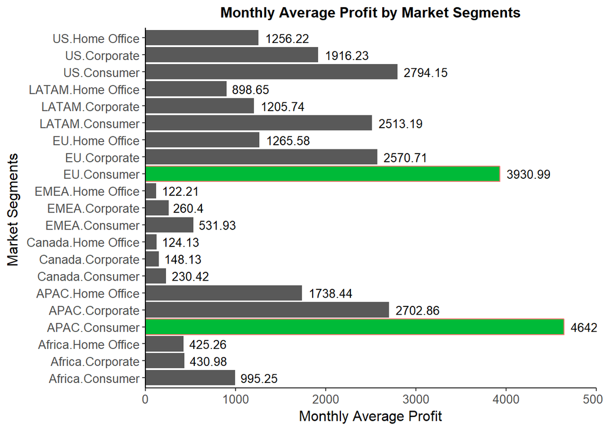

```r
mkt_seg_profits %>%
  ggplot(aes(x = seg_name, y = avg_profit)) +
  geom_col() +
  geom_text(aes(label = avg_profit), hjust = -0.15, size = 3.5) +
  scale_y_continuous(expand = c(0, 0), limits = c(0, 5000)) +
  geom_col(data = mkt_seg_profits %>% filter(avg_profit > 3800),
           col = "#F8766D", fill = "#00BA38") +
  labs(x = "Market Segments ",  y = "Monthly Average Profit",
       title = "Monthly Average Profit by Market Segments") +
  plot_theme +
  coord_flip()
```

Analysing Coefficent of Variance

```r
mkt_seg_profits %>% arrange(cov_profit)
```

```
##              seg_name avg_profit cov_profit
## 1         EU.Consumer    3930.99       0.62
## 2       APAC.Consumer    4642.03       0.63
## 3      LATAM.Consumer    2513.19       0.66
## 4      APAC.Corporate    2702.86       0.70
## 5        EU.Corporate    2570.71       0.76
## 6     LATAM.Corporate    1205.74       0.81
## 7        US.Corporate    1916.23       1.00
## 8         US.Consumer    2794.15       1.01
## 9    APAC.Home Office    1738.44       1.05
## 10     US.Home Office    1256.22       1.10
## 11     EU.Home Office    1265.58       1.12
## 12  LATAM.Home Office     898.65       1.18
## 13    Africa.Consumer     995.25       1.32
## 14    Canada.Consumer     230.42       1.40
## 15   Canada.Corporate     148.13       1.55
## 16   Africa.Corporate     430.98       1.78
## 17 Africa.Home Office     425.26       1.79
## 18      EMEA.Consumer     531.93       2.19
## 19 Canada.Home Office     124.13       2.24
## 20     EMEA.Corporate     260.40       4.47
## 21   EMEA.Home Office     122.21       5.88
```

Plotting Coefficent of Variance

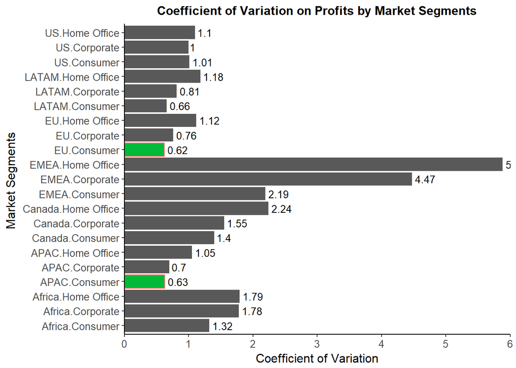

```r
mkt_seg_profits %>%
 ggplot(aes(x = seg_name, y = cov_profit)) +
  geom_col() +
  geom_text(aes(label = cov_profit), hjust = -0.15, size = 3.5) +
  scale_y_continuous(expand = c(0, 0), limits = c(0, 6))  +
  geom_col(data = mkt_seg_profits %>% filter(cov_profit <= 0.63),
           col = "#F8766D", fill = "#00BA38") +
  labs(x = "Market Segments ",  y = "Coefficient of Variation",
       title = "Coefficient of Variation on Profits by Market Segments") +
  plot_theme +
  coord_flip()
```

Both COV and average profits indicate that the most profitable market segments to be:

- APAC consumer
- EA Consumer

*Summary :* APAC consumer and EA Consumer market segments has the least Coefficient of Variance metric  
indicating that these are the consistently performing market segments in terms of profits. We will focus on these market segments during model building, evaluating and forecasting stages.

```r
top_profitable_mrkt_seg <- c("EU.Consumer","APAC.Consumer")
```

## EDA on top profitable time series

Create individual dataframes for top_profitable_mrkt_seg from the mrkt_seg list

```r
list2env(mrkt_seg[top_profitable_mrkt_seg] ,.GlobalEnv)
```

```
## <environment: R_GlobalEnv>
```

Function to explore the 4 market segments timeseries

```
## [1] "Exploratory data analysis on EU Consumer : Sales"
## [1] "ts"
## [1] 2011    1
## [1] 2014   12
## [1] 12
##    Min. 1st Qu.  Median    Mean 3rd Qu.    Max.
##    7553   18925   31352   31869   41772   68952
```

```
##      Jan Feb Mar Apr May Jun Jul Aug Sep Oct Nov Dec
## 2011   1   2   3   4   5   6   7   8   9  10  11  12
## 2012   1   2   3   4   5   6   7   8   9  10  11  12
## 2013   1   2   3   4   5   6   7   8   9  10  11  12
## 2014   1   2   3   4   5   6   7   8   9  10  11  12
```

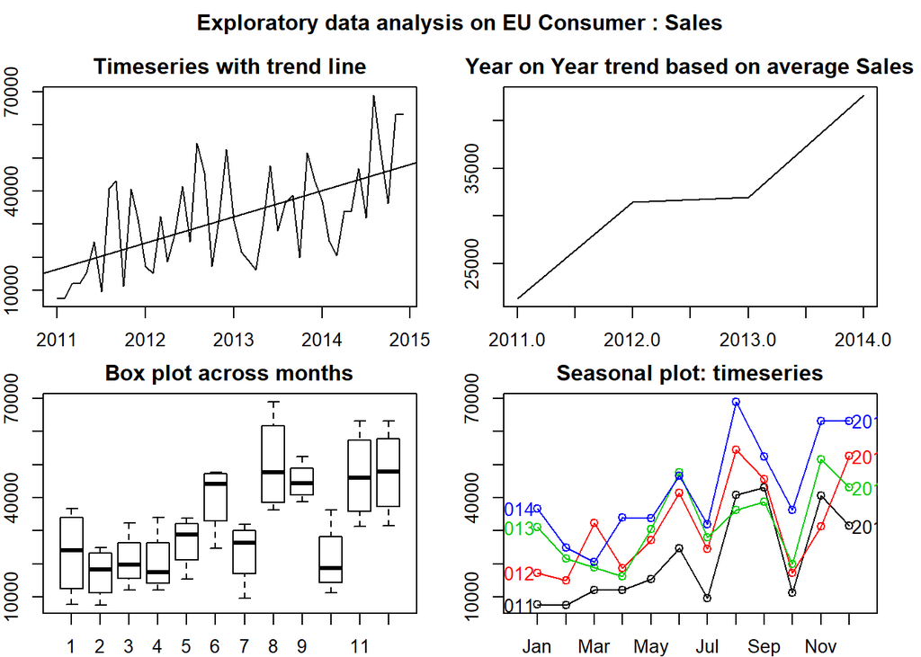

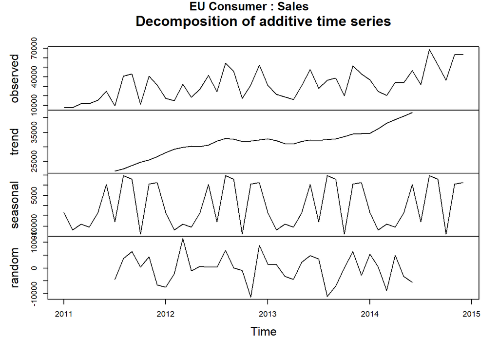

```
## [1] "Exploratory data analysis on EU Consumer : Quantity"
## [1] "ts"
## [1] 2011    1
## [1] 2014   12
## [1] 12
##    Min. 1st Qu.  Median    Mean 3rd Qu.    Max.
##   134.0   242.5   398.0   407.1   518.0   932.0
```

```
##      Jan Feb Mar Apr May Jun Jul Aug Sep Oct Nov Dec
## 2011   1   2   3   4   5   6   7   8   9  10  11  12
## 2012   1   2   3   4   5   6   7   8   9  10  11  12
## 2013   1   2   3   4   5   6   7   8   9  10  11  12
## 2014   1   2   3   4   5   6   7   8   9  10  11  12
```

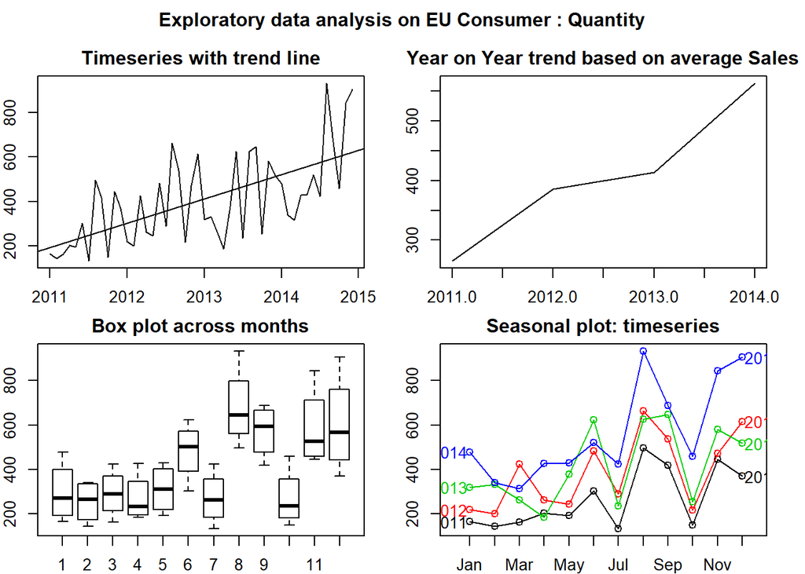

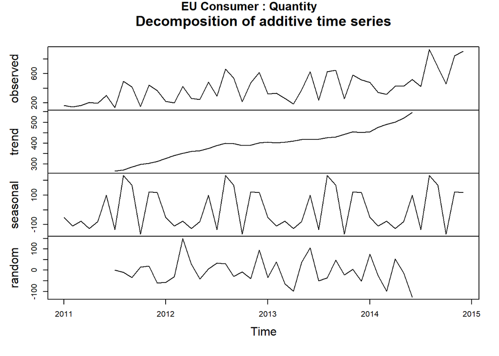

```
## [1] "Exploratory data analysis on APAC Consumer : Sales"
## [1] "ts"
## [1] 2011    1
## [1] 2014   12
## [1] 12
##    Min. 1st Qu.  Median    Mean 3rd Qu.    Max.
##    8390   23765   36498   37849   49205   82286
```

```
##      Jan Feb Mar Apr May Jun Jul Aug Sep Oct Nov Dec
## 2011   1   2   3   4   5   6   7   8   9  10  11  12
## 2012   1   2   3   4   5   6   7   8   9  10  11  12
## 2013   1   2   3   4   5   6   7   8   9  10  11  12
## 2014   1   2   3   4   5   6   7   8   9  10  11  12
```

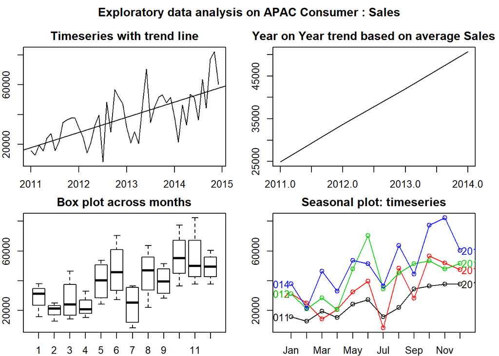

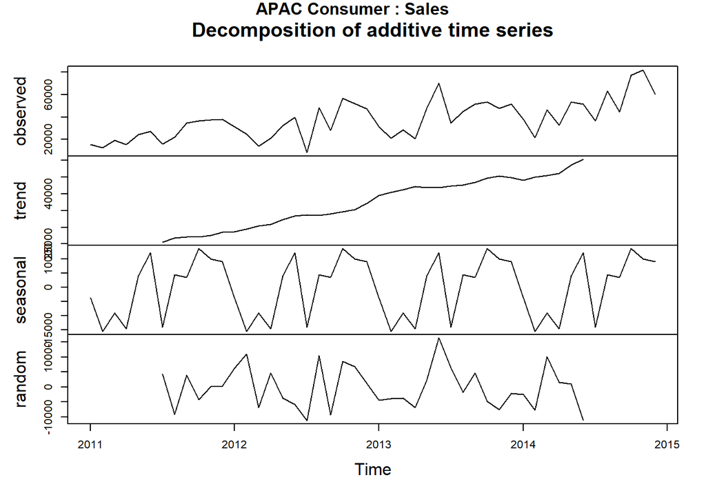

```
## [1] "Exploratory data analysis on APAC Consumer : Quantity"
## [1] "ts"
## [1] 2011    1
## [1] 2014   12
## [1] 12
##    Min. 1st Qu.  Median    Mean 3rd Qu.    Max.
##   132.0   282.0   415.5   446.1   599.8   885.0
```

```
##      Jan Feb Mar Apr May Jun Jul Aug Sep Oct Nov Dec
## 2011   1   2   3   4   5   6   7   8   9  10  11  12
## 2012   1   2   3   4   5   6   7   8   9  10  11  12
## 2013   1   2   3   4   5   6   7   8   9  10  11  12
## 2014   1   2   3   4   5   6   7   8   9  10  11  12
```

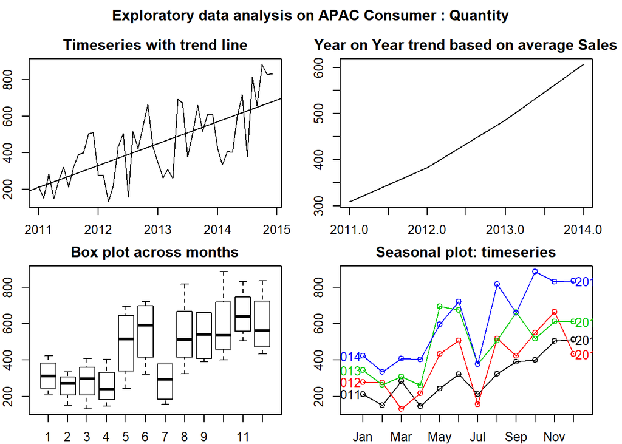

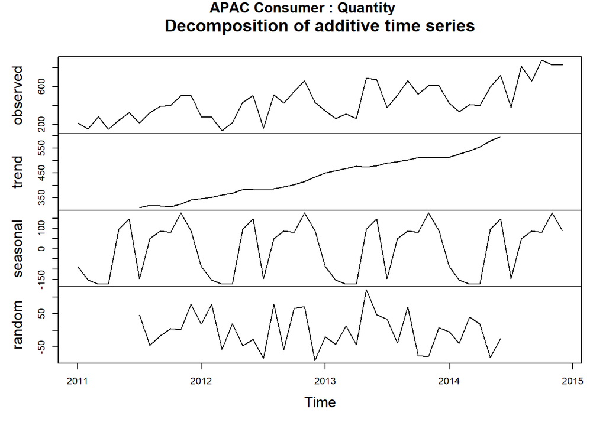

```r
exploreTS <- function(var, segname, varname){
    par(ask = T)
    print(paste("Exploratory data analysis on", segname, ":", varname))

    # Convert data to a time series
    timeseries <- ts(var, start = 2011, frequency = 12)

    print(class(timeseries))    # Tells that the data is in a
                                # time series format
    print(start(timeseries))    # This is the start of the time series
    print(end(timeseries))      # This is the end of the time series
    print(frequency(timeseries))# The cycle of this time series is
                                # 12 months in a year
    print(summary(timeseries))
    op <- par(mfrow = c(2,2), oma = c(0,0,2,0), mar = rep(2, 4))

    plot(timeseries, main = "Timeseries with trend line")

    abline(reg = lm(timeseries~time(timeseries))) # This will fit in a line

    print(cycle(timeseries)) # This will print the cycle across years.

    # This will aggregate the cycles and display a year on year trend
    plot(aggregate(timeseries, FUN = mean),
        main = "Year on Year trend based on average Sales",
        ylab = paste("Average", varname))

    # Box plot across months will give us a sense on seasonal effect
    boxplot(timeseries~cycle(timeseries), main = "Box plot across months",
            xlab = "Month", ylab = paste("Average", varname))

    # Sesonal plot plot across months
    seasonplot(timeseries, year.labels = T, year.labels.left = T,
                col = 1:4, ylab = paste("Average", varname))
    title(paste("Exploratory data analysis on", segname, ":", varname),
          outer = TRUE)

    par(oma = c(0,0,1,0))

    # Visualize timeseries by decomposing the trend, seasonal & random noise
    # componenets
    plot(decompose(timeseries))
    title(paste(segname, ":", varname),
          outer = TRUE)
    par(op)
    par(ask = F)
}

for (i in top_profitable_mrkt_seg) {
  segname <- paste(unique(mrkt_seg[[i]]$Market), unique(mrkt_seg[[i]]$Segment))
  exploreTS(mrkt_seg[[i]]$Sales, segname, "Sales")
  exploreTS(mrkt_seg[[i]]$Quantity, segname, "Quantity")

# Clear temporary variables
remove(i, segname)
}
```

**Summary of findings from Exploratory data analysis:**

**Trend:**

- EU Consumer - Sales/Demand increased in 2012 compared to 2011 and remained somewhat constant in 2013 and again started increasing reaching peak values in 2014.
- APAC Consumer - Sales/Demand has steadily increased from the year 2011 to the year 2014.

**Seasonality from Box plot:**

- EU Consumer - Higher Sales/Demand during Jun, Aug, Sep, Nov & Dec
- APAC Consumer - Higher Sales/Demand during May, Jun, Aug through Dec

## Model Building

```r
EU.Consumer$Month <- seq(1,48)
APAC.Consumer$Month <- seq(1,48)
```

**Common functions**

Smoothen the time series using moving average method. The window selected is 3 i.e average of X - 1, X, X + 1 values

```r
smoothenTS <- function(timeseries, w = 1){

  smseries <- stats::filter(timeseries,
                            filter = rep(1/(2 * w + 1),(2 * w + 1)),
                            method = 'convolution', sides = 2)

  # Smoothing left end of the time series
  diff <- smseries[w + 2] - smseries[w + 1]
  for (i in seq(w,1,-1)) {
    smseries[i] <- smseries[i + 1] - diff
  }

  # Smoothing right end of the time series
  n <- length(timeseries)
  diff <- smseries[n - w] - smseries[n - w - 1]
  for (i in seq(n - w + 1, n)) {
    smseries[i] <- smseries[i - 1] + diff
  }
  lines(smseries, col = "red", lwd = 2)
  return(smseries)
}
```

Exponential smoothing using HoltWinters method. Both Simple moving average and Exponential smoothing was tested and the former was selected for Model building

```r
exposmoothenTS <- function(timeseries, alpha){

  cols <- c("red", "blue", "green", "black")
  labels <- c(paste("alpha =", alpha), "Original")
  for (i in seq(1,length(alpha))) {
    smseries <- HoltWinters(timeser, alpha = alpha[i],
                            beta = FALSE, gamma = FALSE)
    lines(fitted(smseries)[,1], col = cols[i], lwd = 2)
  }
  legend("bottomleft", labels, col = cols, lwd = 2)
}
```

The below function is to convert the passed dataframe into a Time Series object, plot and visualize it

```r
convertTS  <- function(df, salesind) {
  indata <- df[1:42, ]
  if (salesind) {
    timeser <- ts(indata$Sales)
    var = "Sales"
  } else {
    timeser <- ts(indata$Quantity)
    var = "Quantity"
  }
  plot(timeser, main = paste(deparse(substitute(df)),
                             ": ", var, "Time series" ),
       xlab = "Month", ylab = var)

  return(timeser)
}
```

**Classical decomposition - Model Building function**

Steps involved:

1. Fit a model to the global Trend & Seasonality in the smoothened series using regression
2. Remove Trend & Seasonality (the predicted values) from the series. to get a stationary time series(Autoregressive + white noise)
3. Check for Stationarity using ACF & PACF plots
4. Model the stationary series using the auto.arima() function
5. Combine the forecast of this model with the trend and seasonal component
6. Find the residual series by subtracting the forecasted value from the actual observed value.
7. Check if the residual series is pure white noise using ADF & KPSS test.

```r
buildModel <- function(timeser, smoothedseries, lmformula, var) {

  par(ask = T)
  # Building a model on the smoothed time series using classical decomposition
  # First, let's convert the time series to a dataframe

  timevals_in <- seq(1, 42)
  smootheddf <- as.data.frame(cbind(timevals_in, as.vector(smoothedseries)))
  colnames(smootheddf) <- c('Month', var)
  lmfit <- lm(lmformula, data = smootheddf)

  global_pred <- predict(lmfit, Month = timevals_in)
  summary(global_pred)
  lines(timevals_in, global_pred, col = 'green', lwd = 2)

  # Now, let's look at the locally predictable series
  # We will model it as an ARMA series
  local_pred <- timeser - global_pred
  plot(local_pred, col = 'red', type = "l", xlab = "Month", ylab = var,
       main = "Local predictable Series")
  acf(local_pred)
  acf(local_pred, type = "partial")
  print(adf.test(local_pred,alternative = "stationary"))
  print(kpss.test(local_pred))
  # Series is not stationary
  armafit <- auto.arima(local_pred)
  armafit

  # We'll check if the residual series is white noise
  resi <- local_pred - fitted(armafit)
  acf(resi)
  acf(resi, type = "partial")
  print(adf.test(resi, alternative = "stationary"))
  print(kpss.test(resi))

  op <- par(mar = c(3.8,3.8,1.5,1.5))
  tsdiag(armafit)
  par(op)
  par(ask = F)
  return(lmfit)
}
```

**Model building steps:**

1. Convert to Timeseries object
2. Smoothen timeseries & Visualize by plotting
3. Arrive at a formula for fitting the trend & Seasonality in the Series
4. Call buildModel function

**EU Consumer Sales**

```r
salesind = TRUE
timeser           <- convertTS(EU.Consumer, salesind)
```

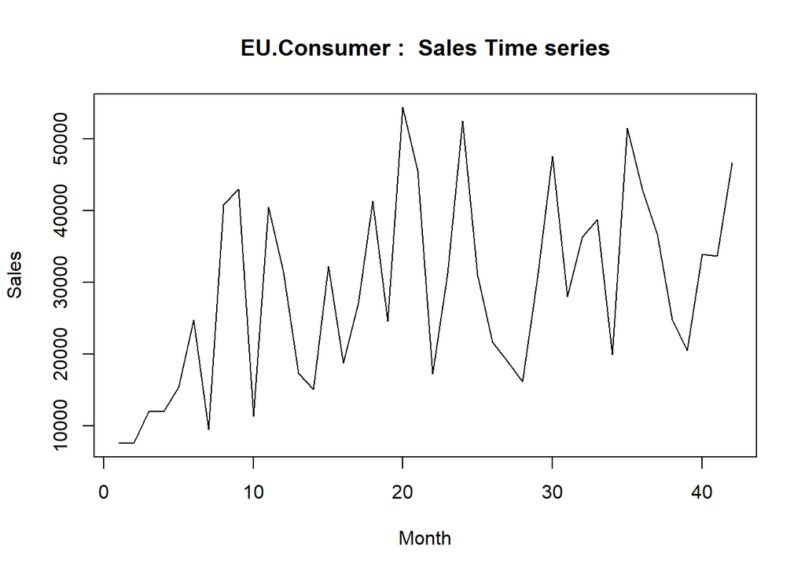

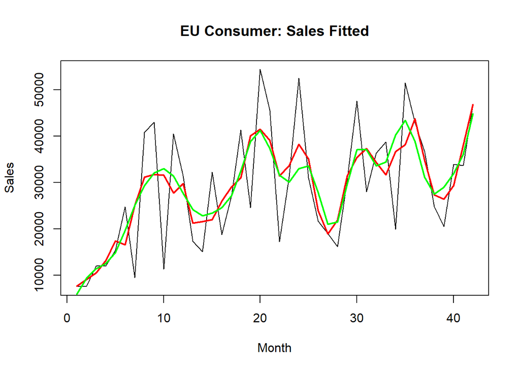

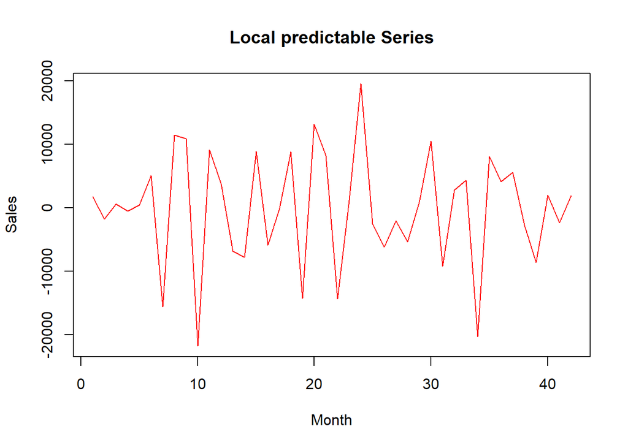

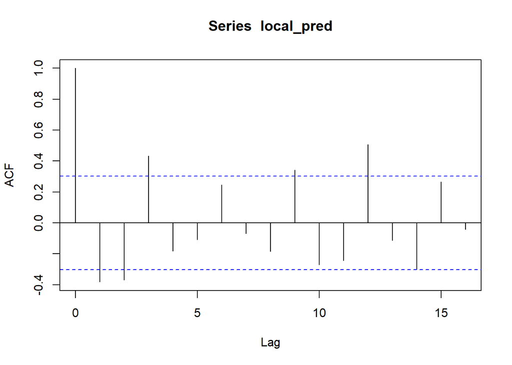

```
##
##  Augmented Dickey-Fuller Test
##
## data:  local_pred
## Dickey-Fuller = -5.0693, Lag order = 3, p-value = 0.01
## alternative hypothesis: stationary
```

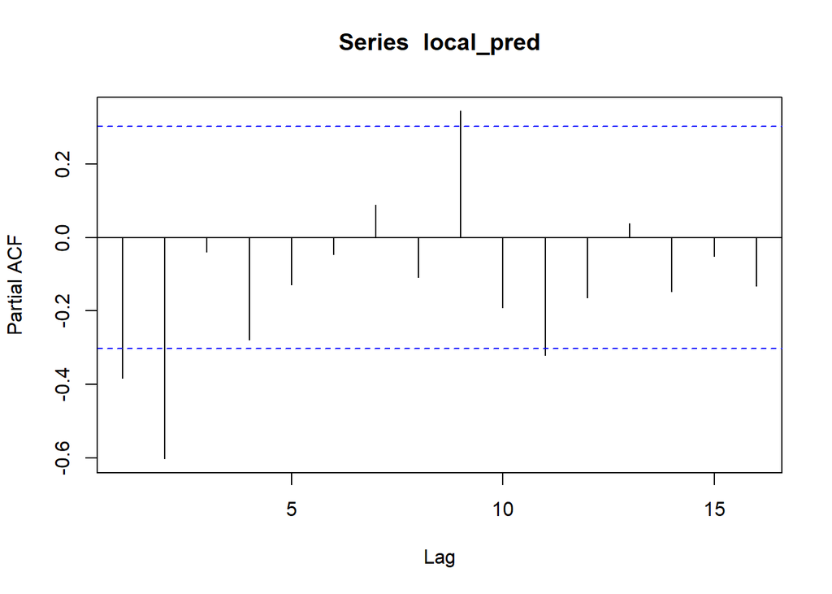

```
##
##  KPSS Test for Level Stationarity
##
## data:  local_pred
## KPSS Level = 0.023684, Truncation lag parameter = 1, p-value = 0.1
```

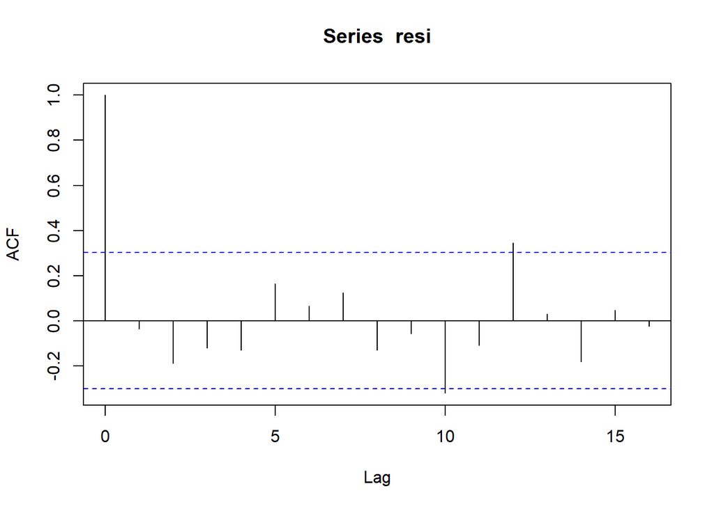

```
##
##  Augmented Dickey-Fuller Test
##
## data:  resi
## Dickey-Fuller = -4.1723, Lag order = 3, p-value = 0.0124
## alternative hypothesis: stationary
```

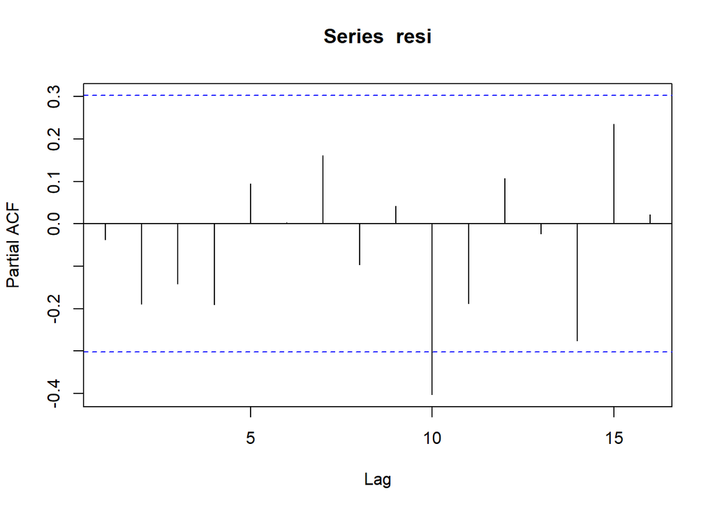

```
##
##  KPSS Test for Level Stationarity
##
## data:  resi
## KPSS Level = 0.059803, Truncation lag parameter = 1, p-value = 0.1
```

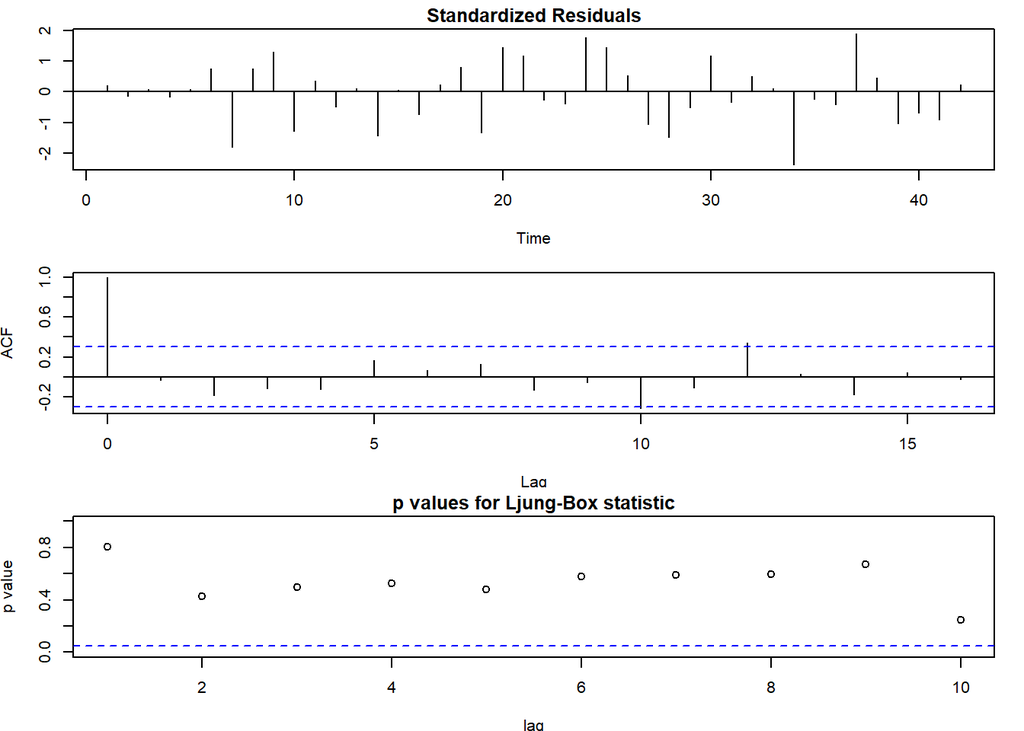

```r
plot(timeser, main = "EU Consumer: Sales Fitted",
     xlab = "Month", ylab = "Sales")
smoothedseries    <- smoothenTS(timeser, 1)
lmformula         <-  as.formula(Sales ~ sin(Month*0.60) *
                                   cos(Month*0.60) *  poly(Month,3))
EU_Sales_model    <- buildModel(timeser, smoothedseries, lmformula, "Sales")
```

The following test results indicates the resulting residual series is stationary ADF test - 0.01 KPSS test - 0.1

**APAC Consumer Sales**

```r
salesind = TRUE
timeser           <- convertTS(APAC.Consumer, salesind)
```

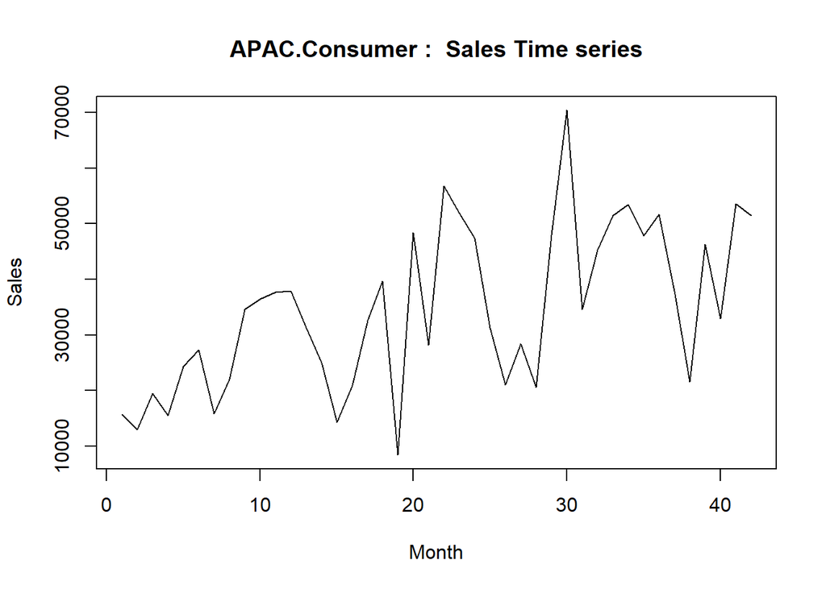

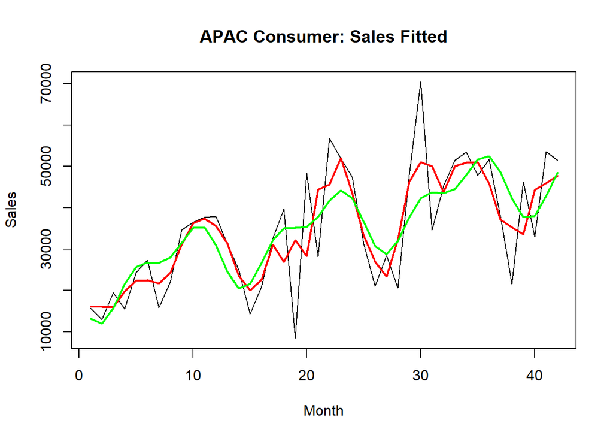

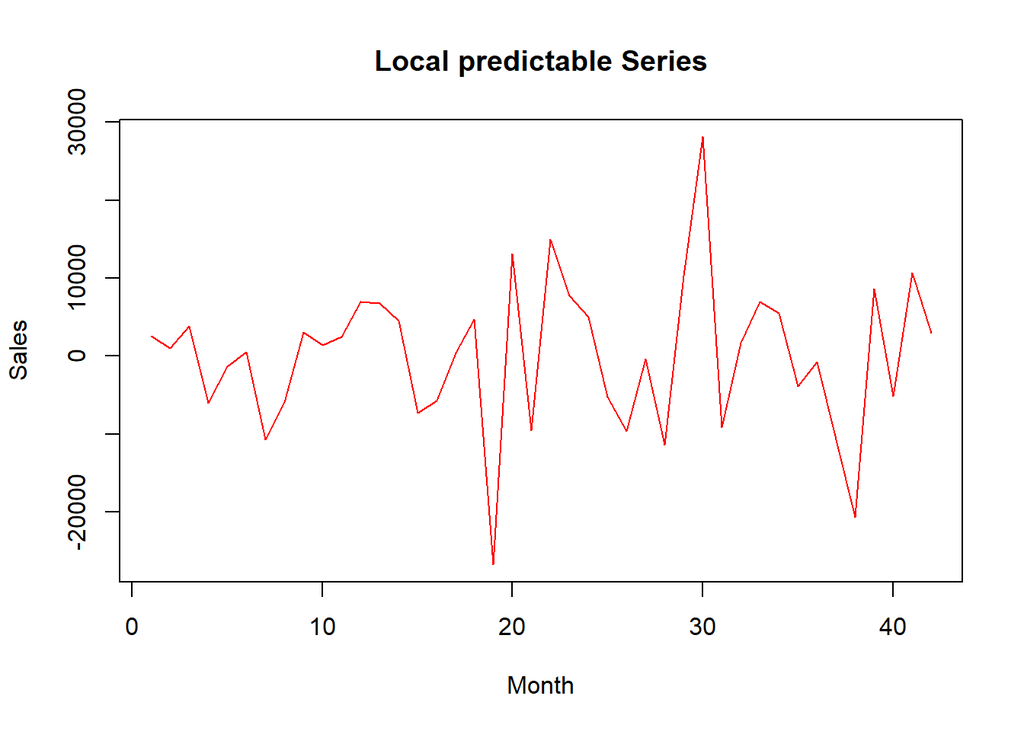

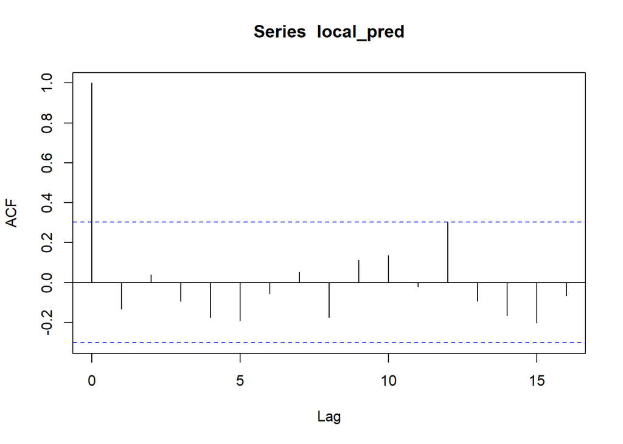

```
##
##  Augmented Dickey-Fuller Test
##
## data:  local_pred
## Dickey-Fuller = -3.7419, Lag order = 3, p-value = 0.03381
## alternative hypothesis: stationary
```

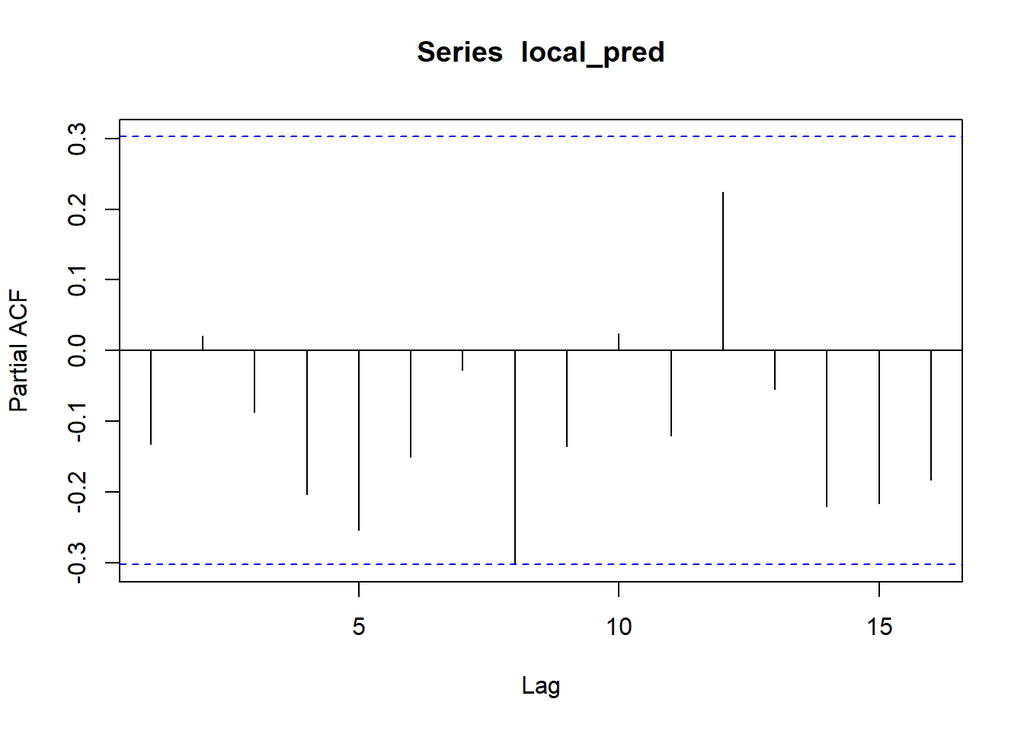

```
##
##  KPSS Test for Level Stationarity
##
## data:  local_pred
## KPSS Level = 0.039685, Truncation lag parameter = 1, p-value = 0.1
```

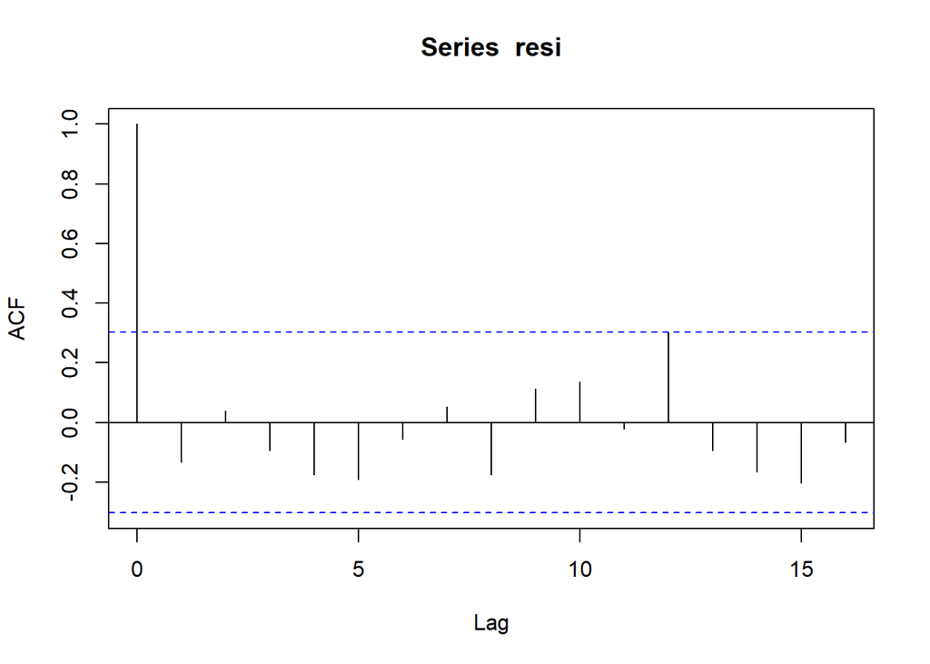

```
##
##  Augmented Dickey-Fuller Test
##
## data:  resi
## Dickey-Fuller = -3.7419, Lag order = 3, p-value = 0.03381
## alternative hypothesis: stationary
```

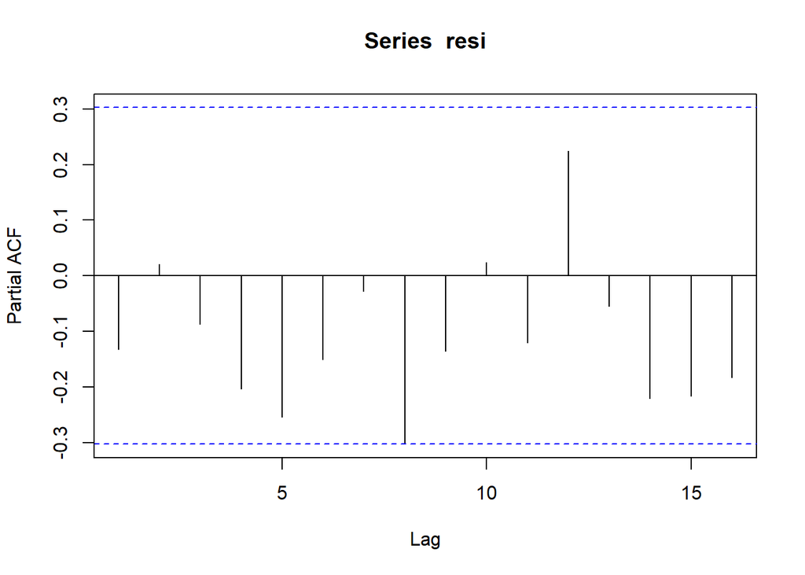

```
##
##  KPSS Test for Level Stationarity
##
## data:  resi
## KPSS Level = 0.039685, Truncation lag parameter = 1, p-value = 0.1
```

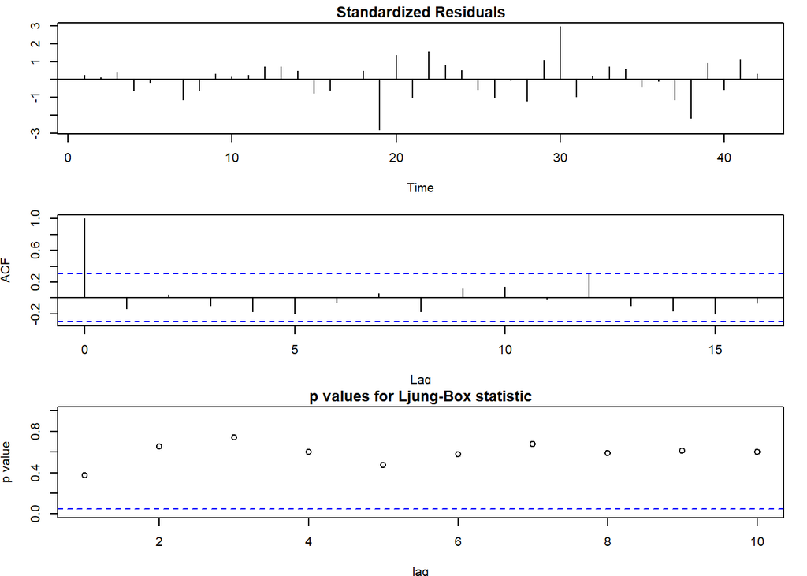

```r
plot(timeser, main = "APAC Consumer: Sales Fitted",
     xlab = "Month", ylab = "Sales")
smoothedseries    <- smoothenTS(timeser, 1)
lmformula         <-  as.formula(Sales ~ sin(Month*0.50) *
                                   cos(Month*0.50) + Month)
APAC_Sales_model  <- buildModel(timeser, smoothedseries, lmformula, "Sales")
```

**EU Consumer Quantity**

```r
salesind = FALSE
timeser           <- convertTS(EU.Consumer, salesind)
```

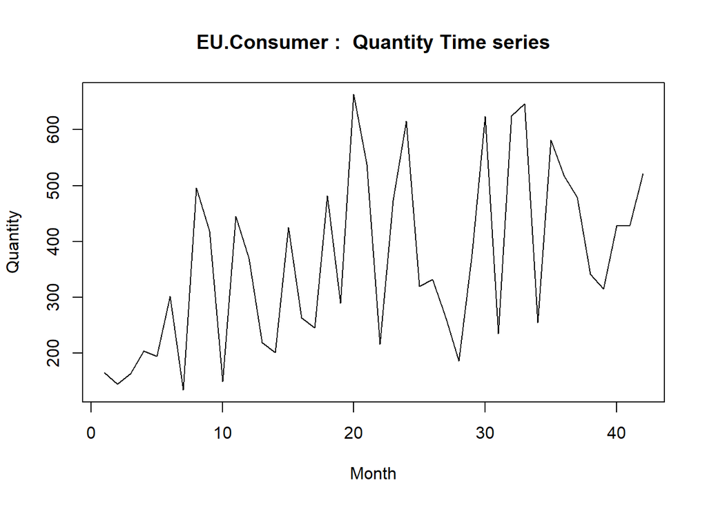